# Read Depths and Duplications

Eric C. Anderson

Last Updated: 2020-05-14

Anaylsis of the duplications between GREB1L and ROCK1 that are associated with run timing.

# Packages and paths

```r
library(tidyverse)
library(plotly)


dir.create("outputs/008", recursive = TRUE, showWarnings = FALSE)
```

# Per-base-pair depth in the 5.16 Mb region (On the cluster, mostly)

## Calculate total read depth at each base pair in the region

For this, we merge all the bams from different individuals into a single one and then use `samtools depth`. This is done on the cluster (not evaluated when rmarkdown document is rendered.)

First, break out that 5.16 Mb region from every bam

```bash
mkdir -p intermediates/008/small_bams

srun -c 5 --pty /bin/bash

module load bio/samtools
for i in chinook_WGS_processed/*.bam; do
  j=$(basename $i);
  samtools view -b -@ 4 $i NC_037124.1:9660000-14825000 >  intermediates/008/small_bams/$j
  samtools index intermediates/008/small_bams/$j
  echo $i
done
```

Then merge all those together.

```bash
samtools merge -f intermediates/008/all-160-merged.bam intermediates/008/small_bams/*.bam
samtools index intermediates/008/all-160-merged.bam
```

Then we find the depth at each position in that file

```bash
samtools depth -a -r NC_037124.1:9660000-14825000 intermediates/008/all-160-merged.bam > intermediates/008/total-depth.tsv
```

### Analyze that in R

We want to make histograms and things.

```r
library(tidyverse)

tot_depths <- read_tsv("intermediates/008/total-depth.tsv", col_names = c("chrom", "pos", "depth"))

mean_depth <- mean(tot_depths$depth)
median_depth <- median(tot_depths$depth)

# results:
# > mean_depth
# [1] 249.4329
# > median_depth
# [1] 238

rd_histo <- ggplot(tot_depths, aes(x = depth)) +
  geom_histogram(binwidth = 10) +
  xlim(0, 2000) +
  geom_vline(xintercept = c(0.5, 1, 2) * mean_depth, colour = "red") +
  geom_vline(xintercept = c(0.5, 1, 2) * median_depth, colour = "blue")

# write that ggplot out to stored_results to put it in a notebook
write_rds(rd_histo, path = "stored_results/008/rd_histo.rds", compress = "xz")
```

Here we will plot that histogram locally:

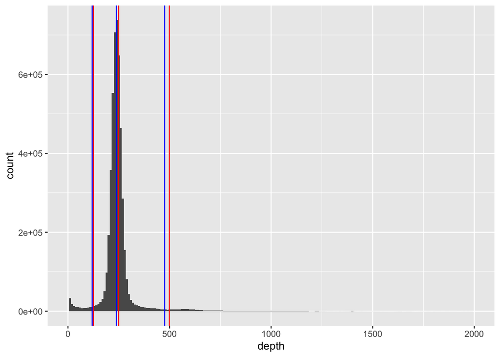

```r
rd_histo <- read_rds("stored_results/008/rd_histo.rds")
rd_histo
```

The blue lines show the median (and the 0.5 and 2.0 cutoffs), and the red lines show the same for the mean.

That shows a fairly small difference between the mean and the median. But the median makes more sense to me in this context for the “background” level of depth. So, we will use that to define our sites that we “keep”: those between 0.5 and twice the “background.”

```r
keep_sites <- tot_depths %>%
  filter(depth > 0.5 * median_depth & depth < 2 * median_depth)
```

That is 4,668,074 sites retained out of the total 5,165,000.

```r
cat(keep_sites$pos, sep="\n", file = "intermediates/008/keeper_sites.txt")
```

## Now get the mean read depth of each sample over those “kept” sites

We will use samtools depth to get those values. We are going to do that in a job array. But we will pipe the output to something that will just keep the keeper sites, in awk, and compute the mean depth at them.

```bash
# prepare
mkdir -p intermediates/008/{slurm_out,slurm_err,sb_depths}

ls -l intermediates/008/small_bams/*.bam | awk 'BEGIN {printf("index\tfile\n");} {printf("%d\t%s\n", ++idx, $NF);}' > intermediates/008/file-list.tsv

sbatch ./script/008-read-depth-array.sh

# that is very quick.  And when we are done with
# it we can catenate the results into stored results
cat intermediates/008/sb_depths/0*.txt > stored_results/008/per-base-mean-depth-by-reviewer-recommendation.txt
```

## Compare results with the “old way” we did it

We had previously used a different criterion for filtering sites. We want to compare those results to what we get using the reviewer-recommended method. Our previous results are in `stored_results/008/old-way-average-read-depths-near-greb1.tsv`.

```r
new_depths <- read_tsv("stored_results/008/per-base-mean-depth-by-reviewer-recommendation.txt",
  col_names = c("vcf_name", "num_bp_in_keepers", "tot_keepers", "mean_read_depth")
) %>%
  mutate(vcf_name = str_replace(vcf_name, "\\.rmdup.*$", ""))
old_depths <- read_tsv("stored_results/008/old-way-average-read-depths-near-greb1.tsv")
```

Make a plot of the distribution of new depth values:

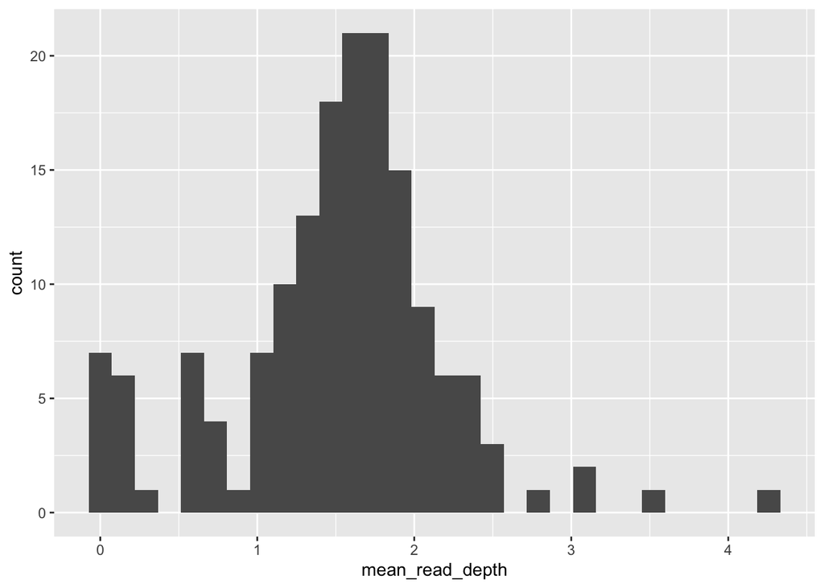

```r
ggplot(new_depths, aes(x = mean_read_depth)) +
  geom_histogram()
```

So, we still have the same 14 problematic individuals with read depth < 0.5X. Look at the first 20 here:

```r
nd_arr <- new_depths %>%
  select(vcf_name, mean_read_depth) %>%
  arrange(mean_read_depth) %>%
  slice(1:20)

nd_arr
```

| vcf_name | mean_read_depth |
| --- | --- |
| DPCh_plate1_B03_S15 | 0.0130528 |
| DPCh_plate1_C04_S28 | 0.0153692 |
| DPCh_plate1_B01_S13 | 0.0247096 |
| DPCh_plate1_C01_S25 | 0.0268668 |
| DPCh_plate1_F01_S61 | 0.0331494 |
| DPCh_plate1_E03_S51 | 0.0541910 |
| DPCh_plate1_E04_S52 | 0.0585809 |
| DPCh_plate1_B04_S16 | 0.0768972 |
| DPCh_plate1_G04_S76 | 0.0859342 |
| DPCh_plate1_H03_S87 | 0.1216720 |

[output cut: 10 more lines]

While we are at it, we will write those 14 names to a file to make sure that we can remove them in later analyses if need be. We will put these in stored results.

```r
nd_arr %>%
  filter(mean_read_depth < 0.5) %>%
  pull(vcf_name) %>%
  cat(., sep = "\n", file = "stored_results/008/14-low-read-depth-drop-indivs.txt")
```

Let’s also print those out with some meta data:

```r
read_csv("data/wgs-chinook-samples.csv") %>%
  left_join(nd_arr %>% filter(mean_read_depth < 0.5), .) %>%
  select(-(ID_Berk:BOX_POSITION))
```

| vcf_name | mean_read_depth | Population | Concentration (ng/ul) | run_type |
| --- | --- | --- | --- | --- |
| DPCh_plate1_B03_S15 | 0.0130528 | Salmon River Spring | 10.60 | Spring |
| DPCh_plate1_C04_S28 | 0.0153692 | Salmon River Spring | 13.30 | Spring |
| DPCh_plate1_B01_S13 | 0.0247096 | Salmon River Fall | 13.50 | Fall |
| DPCh_plate1_C01_S25 | 0.0268668 | Salmon River Fall | 5.82 | Fall |
| DPCh_plate1_F01_S61 | 0.0331494 | Salmon River Fall | 6.30 | Fall |
| DPCh_plate1_E03_S51 | 0.0541910 | Salmon River Spring | 15.70 | Spring |
| DPCh_plate1_E04_S52 | 0.0585809 | Salmon River Spring | 10.80 | Spring |
| DPCh_plate1_B04_S16 | 0.0768972 | Salmon River Spring | 55.00 | Spring |
| DPCh_plate1_G04_S76 | 0.0859342 | Salmon River Spring | 5.80 | Spring |
| DPCh_plate1_H03_S87 | 0.1216720 | Salmon River Spring | 5.56 | Spring |

[output cut: 4 more lines]

Finally, compare the values between our old way of doing it (filtering out windows of excessive read depth) and the preferable approach suggested by the referee:

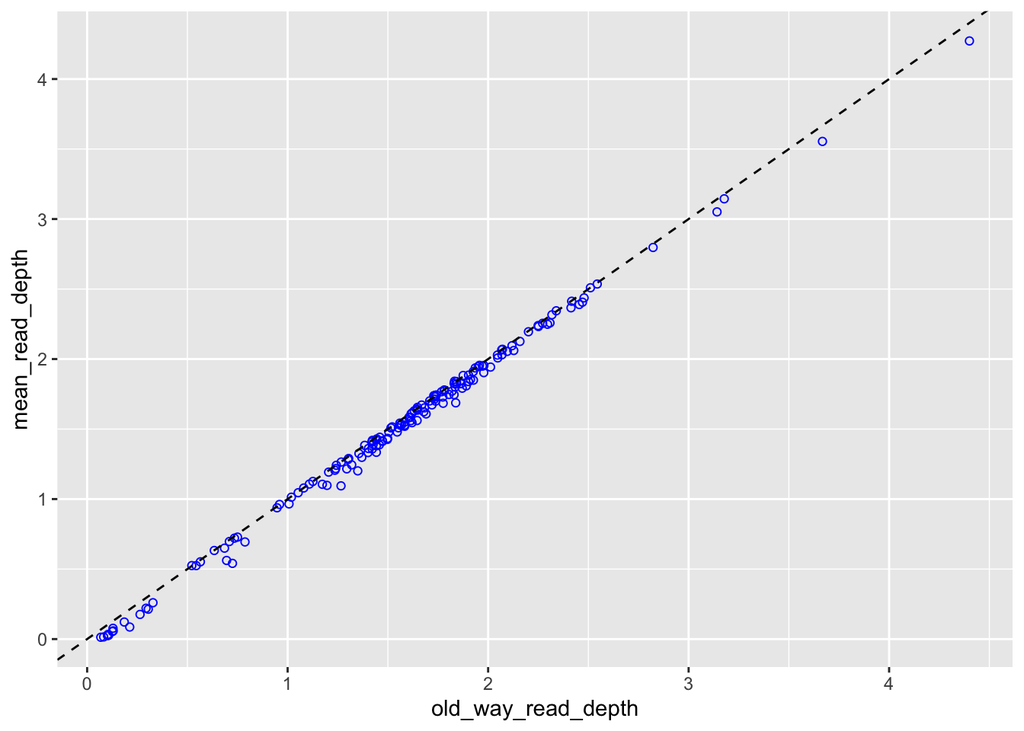

```r
new_depths %>%
  left_join(old_depths, by = "vcf_name") %>%
  ggplot(aes(x = old_way_read_depth, y = mean_read_depth)) +
  geom_point(shape = 21, colour = "blue") +
  geom_abline(intercept = 0, slope = 1, linetype = "dashed")
```

# Getting Read Depths

Looking at the haplo-raster of read depth (from 006) it looks to be quite clear that the fall run has a duplicated region just to the right of the right-most Tasha SNP. Here, we visually demarcate that region, and then we compare the expected number of reads in that region (using just the individuals that look non-duplicated) to the observed number, amongst the fish that look to have the duplication to see if we can see how many duplicates there are.

# Getting indiviual-specific read depths across the whole 5.16 Mb region

We want the total number of reads spanning that whole region for each individual. This gives us a measure of expecte number of reads for each individual over a large swath of genome.

This is quick with bedtools, but requires all the BAMs (which are not included in this repo). But the code we used is included here for those who have generated the BAMs.

```bash
# we have a bed file to grab that region.  cat it to see it has one line in it.
cat dupie-region/5.16Mb.bed
#NC_037124.1    9660000 14825000    5.16Mb_chunk

# use bedtools multicov
bedtools multicov -bams nmfs-chinook-NC_037124.1-bams/*.bam -bed dupie-region/5.16Mb.bed > dupie-region/5.16Mb.multicov

# record the names of the fish so we have that:
ls -l nmfs-chinook-NC_037124.1-bams/*.bam | awk '{n=$NF; sub(/^.*NC_037124.1-/, "", n); sub(/\.rmdup.bam/,"", n); print n}' > dupie-region/bam-fish-names.txt
```

That produced two files that we have included in the repo here in directory `stored_results`:

```
./stored_results/008/5.16Mb.multicov
./stored_results/008/bam-fish-names.txt
```

## Getting per-bp read depths for each individual across 30K base pairs where the duplications are prevalent.

This is actually quite computationally intensive. The following code documents how I ended up doing it in a job array.

```bash
echo NC_037124.1 | awk '{for(b=12300000;b<=12330000;b++) printf("%s\t%d\t%d\t%s:%d\n", $1, b, b, $1, b)}' > dupie-region/every-bp.bed

# then set it off to estimate how much time it will take.
bedtools multicov -bams nmfs-chinook-NC_037124.1-bams/*.bam -bed dupie-region/every-bp.bed > dupie-region/every-bp.multicov
```

That got through about 10,000 bp in two hours. I’m sure there is a much faster way of doing it, but at this point I just want to finish it up. So, here is what we do:

1. Put the bams on flash scratch
2. Run a job array with each job doing 1,000 bp (should take about 12 minutes. So, we will give each job an hour and that should be plenty.)

We first make 21 files numbered 001 to 021 that have 1000 bp segments (apart from the first two).

```bash
# in /u/home/e/eriq/nobackup-kruegg/osu-chinook-nobackup/dupie-region
mv every-bp.multicov 001-every-bp.multicov
awk '$2 <= 12310665' every-bp.bed > 001-every-bp.bed
awk '$2 > 12310665 && $2 <= 12311000' every-bp.bed > 002-every-bp.bed

# now, from here we just want to put out a different file for every 1000 from 12311001 to 12330000.
# that sounds like a job for awk.
echo NC_037124.1 | awk '
   BEGIN {F=3;}
   {for(b=12311001;b<=12330000;b++) {
      ++n;
      file=sprintf("%03d-every-bp.bed", F);
      printf("%s\t%d\t%d\t%s:%d\n", $1, b, b, $1, b) > file;
      if(n % 1000 == 0) {
         close(file); F++;
      }
    }
    }'
```

That creates a bunch of files like: `004-every-bp.bed`.

Then, make a job array script to crunch those all out:

```bash
#!/bin/bash
#$ -cwd
#$ -V
#$ -N every-bp
#$ -o every-bp-$TASK_ID.log
#$ -e every-bp-$TASK_ID.error
#$ -l h_data=4G,time=1:00:00
#$ -M eric.anderson@noaa.gov
#$ -t 1-21:1  # 2-21
#$ -m a



source /u/local/Modules/default/init/modules.sh
module load bedtools


INBED=$(printf "%03d-every-bp.bed" $SGE_TASK_ID)
OUTF=${INBED/.bed/.multicov}

bedtools multicov -bams /u/flashscratch/e/eriq/full-wgs-chinook-data/nmfs-chinook-NC_037124.1-bams/*.bam -bed $INBED > $OUTF
```

Launch with:

```bash
qsub every-bp-job-array.sh
```

When it was done we did:

```bash
cat 0*.multicov > NC_037124.1-12300000-12330000.multicov

# check how many lines
wc NC_037124.1-12300000-12330000.multicov
#   30001  4920164 11155429 NC_037124.1-12300000-12330000.multicov
```

And, we’ve put the result into this repository, in `./stored_results/008/NC_037124.1-12300000-12330000.multicov.gz`.

# Computing predicted and observed reads at an aggregate level

First, read the results in and wrangle into tidy format and join with meta data

```r
meta <- read_csv("data/wgs-chinook-samples.csv") %>%
  mutate(pop = str_replace_all(Population, "Spring|Late Fall|Fall", "") %>%
    str_replace_all(., "Hatchery", "H.") %>%
    str_replace_all(., "Creek", "Ck.") %>%
    str_replace_all(., "River", "R."))
bammy <- read_lines("stored_results/008/bam-fish-names.txt")

mb516 <- read_tsv("stored_results/008/5.16Mb.multicov", col_names = FALSE) %>%
  setNames(c("chrom", "start", "stop", "int_name", bammy)) %>%
  gather(., key = "vcf_name", value = "reads", -(chrom:int_name)) %>%
  left_join(meta, by = "vcf_name") %>%
  mutate(group = ifelse(run_type == "Spring", "Spring", "FLFW"))

bpcov <- read_tsv("stored_results/008/NC_037124.1-12300000-12330000.multicov.gz", col_names = FALSE) %>%
  setNames(c("chrom", "start", "stop", "int_name", bammy)) %>%
  gather(., key = "vcf_name", value = "reads", -(chrom:int_name)) %>%
  left_join(meta, by = "vcf_name") %>%
  mutate(group = ifelse(run_type == "Spring", "Spring", "FLFW"))
```

Now, we can start compiling some things.

```r
# first get total number of reads in the 5.16 Mb region for both groups
tmp <- mb516 %>%
  group_by(group) %>%
  summarise(tot_read = sum(reads))
Tflfw <- tmp$tot_read[tmp$group == "FLFW"]
Tspring <- tmp$tot_read[tmp$group == "Spring"]

# then get the number of reads for each base pair for each of them
pred_depths <- bpcov %>%
  group_by(group, start) %>%
  summarise(Xb = sum(reads)) %>%
  rename(pos = start) %>%
  spread(key = group, value = Xb) %>%
  mutate(pred_FLFW = Spring * Tflfw / Tspring) %>%
  mutate(obs_pred_ratio = FLFW / pred_FLFW)
```

Now, let’s make an initial picture of that to see what it looks like.

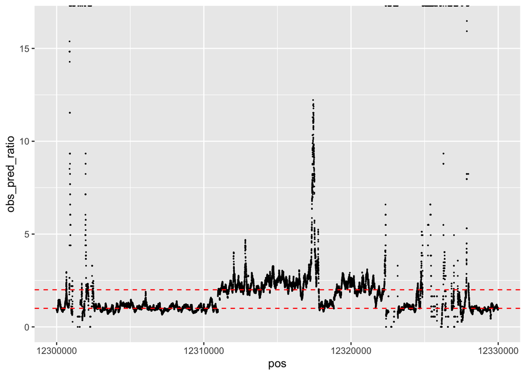

```r
g <- ggplot(pred_depths, aes(x = pos, y = obs_pred_ratio)) +
  geom_point(size = 0.1) +
  geom_hline(yintercept = c(1, 2), linetype = "dashed", colour = "red")

# ggplotly(g)
g
```

By fiddling with the above figure using ggplotly, it looks like some intervals with a 2:1 duplication reside amongst other intervals that are 1:1 or quite ridiculously high.

```
NC_037124.1 12302800    12310950    Mostly_1
NC_037124.1 12311027    12314175    Mostly_2
NC_037124.1 12314176    12316545    Above_2
NC_037124.1 12317306    12317786    Wacky_high
NC_037124.1 12317958    12318837    Near_1_again
NC_037124.1 12319007    12321906    Around_2_again
NC_037124.1 12323456    12324276    Back_to_1_short
NC_037124.1 12328219    12330000    Back_to_1_right
```

## Assessing repeat masked status

Before I get onto that, though, I want to color each position by whether it is soft-masked (lowercase) in the Chinook reference genome, or not. We get the appropriate piece of the fasta like this:

```bash
samtools faidx genome/Otsh_v1.0_genomic.fna NC_037124.1:12300000-12330000 > inputs/NC_037124.1-12300000-12330000.fna
```

And I put the result into this repo in: `./stored_results/008/NC_037124.1-12300000-12330000.fna.gz`.

Now, slurp that sequence out and blow it up into a tibble:

```r
fasta_lines <- read_lines("stored_results/008/NC_037124.1-12300000-12330000.fna.gz")[-1]
fasta_vec <- paste(fasta_lines, collapse = "") %>%
  strsplit(., "") %>%
  `[[`(1)
bases <- tibble(
  pos = seq(from = 12300000, by = 1, length = length(fasta_vec)),
  ref = fasta_vec
) %>%
  mutate(repeat_status = ifelse(str_detect(ref, "[a-z]"), "soft-masked", "not masked"))
```

And join it to pred depths and replot, along with the domains we defined above.

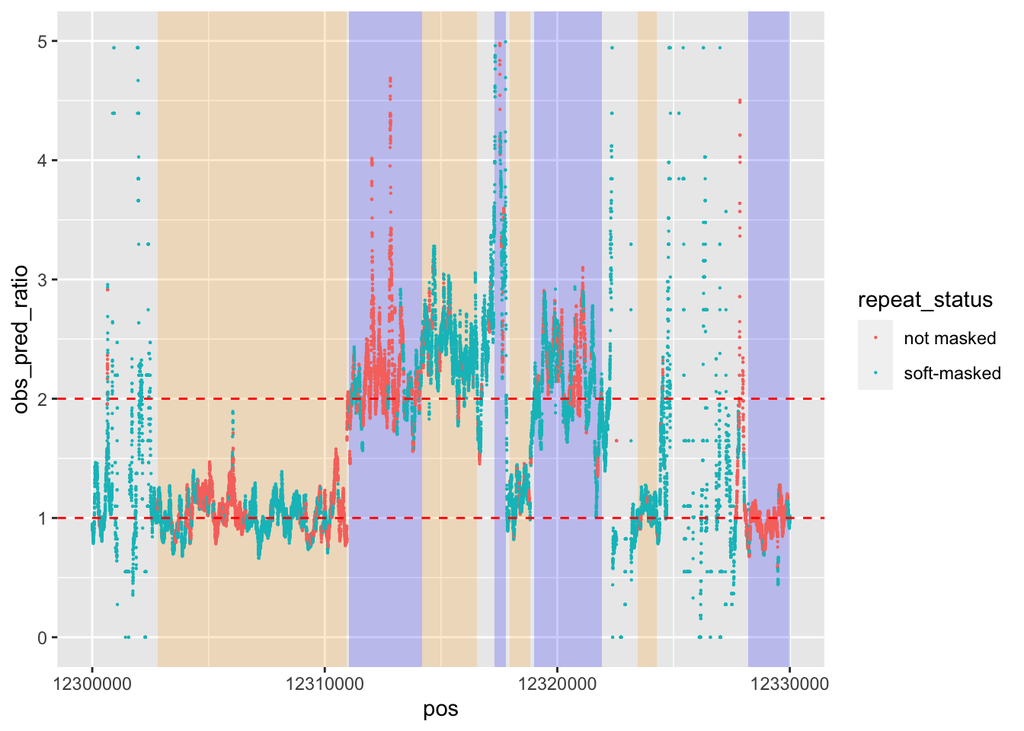

```r
pred_depths2 <- pred_depths %>%
  left_join(bases, by = "pos")

# get the domains that we defined above, too
domains <- read_tsv("stored_results/008/rough-dupie-regions.bed",
  col_names = c("chrom", "start", "stop", "name")
)

odds <- domains %>% slice(seq(1, n(), by = 2))
evens <- domains %>% slice(seq(2, n(), by = 2))


# Plot this, but drop points at which the spring run have zero reads observed
g2 <- ggplot() +
  geom_rect(data = odds, mapping = aes(xmin = start, xmax = stop), ymin = -Inf, ymax = Inf, fill = "orange", colour = NA, alpha = 0.2) +
  geom_rect(data = evens, mapping = aes(xmin = start, xmax = stop), ymin = -Inf, ymax = Inf, fill = "blue", colour = NA, alpha = 0.2) +
  geom_point(data = pred_depths2 %>% filter(Spring > 0), mapping = aes(x = pos, y = obs_pred_ratio, colour = repeat_status), size = 0.1) +
  geom_hline(yintercept = c(1, 2), linetype = "dashed", colour = "red") +
  ylim(0, 5)

g2
```

## Make a final figure

Before we continue, let us make a more production-ready figure that just shows the regions that we will call “Doubles” and those that we will call “Singles”. We will use those later to look at the individual depths.

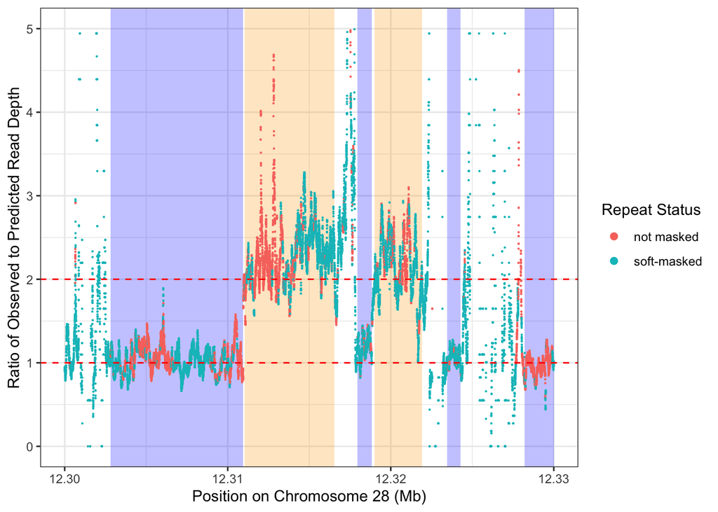

```r
Singles <- domains %>%
  filter(str_detect(name, "1"))
Doubles <- domains %>%
  filter(str_detect(name, "2"))


g100 <- ggplot() +
  geom_rect(data = Doubles, mapping = aes(xmin = start / 1e6, xmax = stop / 1e6), ymin = -Inf, ymax = Inf, fill = "orange", colour = NA, alpha = 0.25) +
  geom_rect(data = Singles, mapping = aes(xmin = start / 1e6, xmax = stop / 1e6), ymin = -Inf, ymax = Inf, fill = "blue", colour = NA, alpha = 0.25) +
  geom_point(data = pred_depths2 %>% filter(Spring > 0), mapping = aes(x = pos / 1e6, y = obs_pred_ratio, colour = repeat_status), size = 0.1) +
  geom_hline(yintercept = c(1, 2), linetype = "dashed", colour = "red") +
  ylim(0, 5) +
  ylab("Ratio of Observed to Predicted Read Depth") +
  xlab("Position on Chromosome 28 (Mb)") +
  guides(colour = guide_legend(
    title = "Repeat Status",
    override.aes = list(size = 2)
  )) +
  theme_bw()

ggsave(g100, filename = "outputs/008/aggregate-read-depth-lines.pdf", width = 7, height = 5)
g100
```

# Computing observed vs predicted reads on an individual level

We take our rough-dupie regions and get numbers of reads overlapping those regions.

```bash
bedtools multicov -bams /Volumes/KanaloaEXTRA/chinook_WGS_processed_large_contigs/*.bam  -bed rough-dupie-regions.bed > rough-dupie-regions.multicov
# that is really quick.
```

The output is stored in the repo in: `./stored_results/008/rough-dupie-regions.multicov`

We use that output to look at the number of reads on a per-individual basis.

```r
# get it all into a data frame
rdrm <- read_tsv("stored_results/008/rough-dupie-regions.multicov", col_names = FALSE) %>%
  setNames(c("chrom", "start", "stop", "int_name", bammy)) %>%
  gather(., key = "vcf_name", value = "reads", -(chrom:int_name)) %>%
  left_join(meta, by = "vcf_name") %>%
  mutate(group = ifelse(run_type == "Spring", "Spring", "FLFW")) %>%
  mutate(Ecotype = str_c(run_type, " Run")) %>%
  mutate(Domain = factor(int_name, levels = domains$name))
```

Now, we will predict each individual’s read depth as a function of the spring run read depth. First get the total spring read depths in each domain and join that to the data frame domain-specific reads with spring. And also join the total number of reads in the 5.16 Mb region at each individual on there, and then compute the simple predicted values.

```r
sorty <- rdrm %>%
  arrange(Domain, Ecotype, reads) %>%
  group_by(Domain) %>%
  mutate(Index = 1:n())

dsrws <- sorty %>%
  filter(run_type == "Spring") %>%
  group_by(Domain) %>%
  summarise(tot_spring_reads_in_domain = sum(reads)) %>%
  ungroup() %>%
  left_join(sorty, ., by = "Domain") %>%
  left_join(., mb516 %>% select(vcf_name, reads) %>% rename(tot_reads_516 = reads), by = "vcf_name") %>%
  mutate(pred_domain_reads = tot_reads_516 * tot_spring_reads_in_domain / Tspring)
```

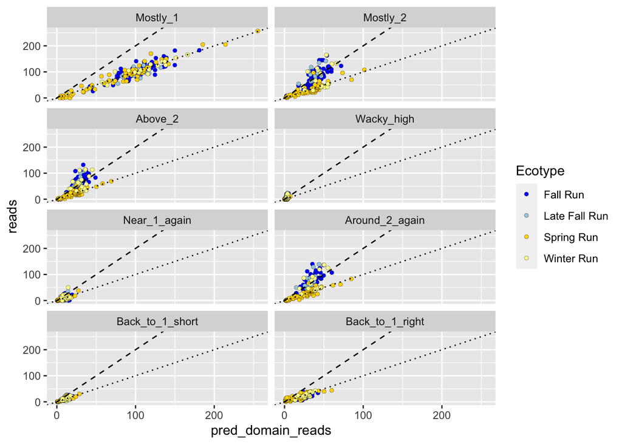

```r
# get our color scheme
source("R/define_fcolors_all_sf.R")

# now plot it in a big plot, faceted by domain, and coloured by Ecotype
g <- ggplot(dsrws, aes(x = pred_domain_reads, y = reads, fill = Ecotype)) +
  geom_point(shape = 21, stroke = 0.1) +
  scale_fill_manual(values = fcolors_all_sf) +
  facet_wrap(~Domain, ncol = 2) +
  geom_abline(intercept = 0, slope = 1, linetype = "dotted") +
  geom_abline(intercept = 0, slope = 2, linetype = "dashed")

g
```

That is quite clear and interesting. And it would be interesting to follow up on the fish that have higher or lower read depth than expected here. Of interest in the region is the fact that some of the fish appear to be heterozygous in that duplicated region (in terms of the alleles they carry), but then some of the fish that are heterozygous across most of that region are homozygous for the spring run allele (this is especially the case in the Feather River spring run). Interesting.

## Check out the allelic variation in there

Looking at some of the raster plots, it appears that none of the Feather River Spring are homozygous for the alleles associated with the duplicated (“fall”) form of the haplotype, but some are heterozygous. So, let’s pull those haplotypes out and filter down to just the duplicated region:

```r
dr_bh <- read_rds(path = "outputs/004/big_haps2.rds") %>%
  filter(POS > 12311027 & POS < 12321906)
```

Look at the distribution of the number of S vs F alleles on each haplotype, according to their ecotype.

```r
NumS_alle <- dr_bh %>%
  group_by(Indiv, haplo_name, ecotype) %>%
  summarise(
    numS_alleles = sum(alle2 == "S"),
    fracS_alleles = numS_alleles / n()
  )
```

And now make a histogram of that:

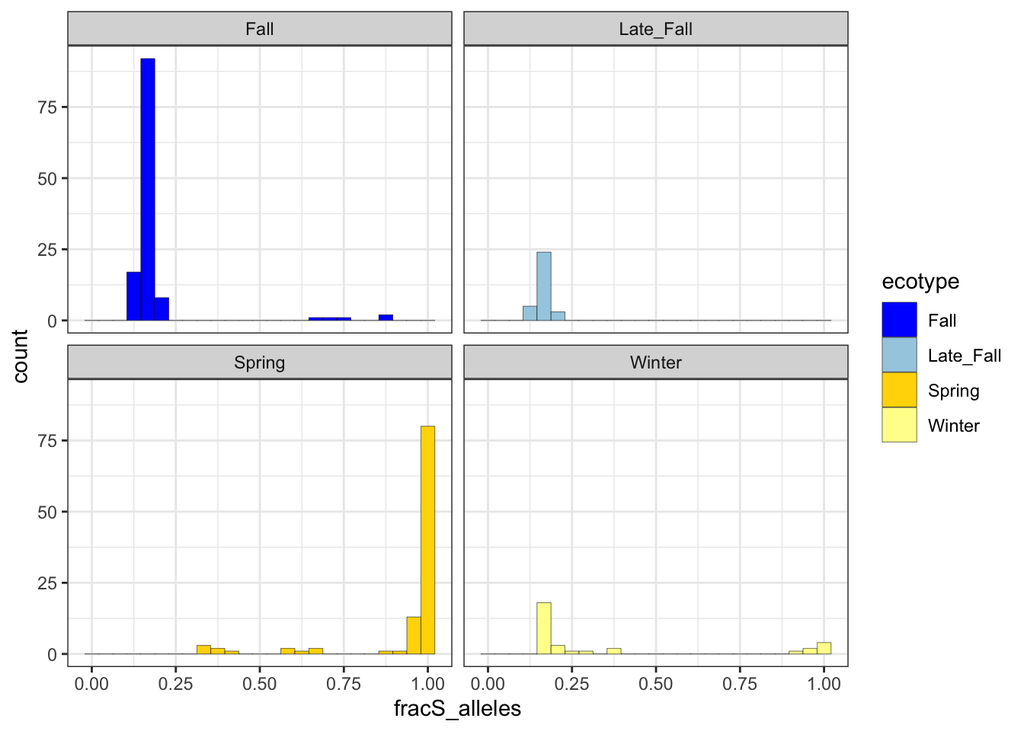

```r
ggplot(NumS_alle, aes(x = fracS_alleles, fill = ecotype)) +
  geom_histogram(bins = 25, colour = "black", size = 0.1) +
  facet_wrap(~ecotype) +
  expand_limits(x = 0) +
  scale_fill_manual(values = fcolors_all_sf) +
  theme_bw()
```

OK, that shows there are clearly two different classes. And it appears that there is some uncertainty, probably in heterozygous individuals, so, let’s see where these values fall out for entire individuals, not just the haplotypes within them.

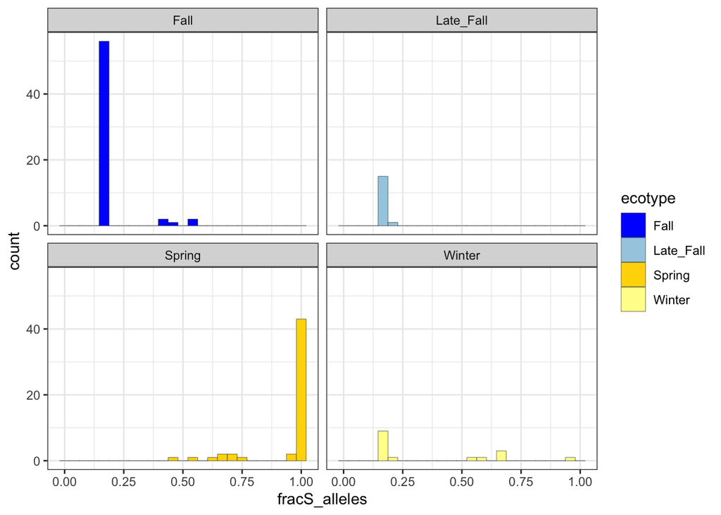

```r
NumS_alle_by_indiv <- NumS_alle %>%
  group_by(Indiv, ecotype) %>%
  summarise(
    numS_alleles = sum(numS_alleles),
    fracS_alleles = mean(fracS_alleles)
  )

ggplot(NumS_alle_by_indiv, aes(x = fracS_alleles, fill = ecotype)) +
  geom_histogram(bins = 25, colour = "black", size = 0.1) +
  facet_wrap(~ecotype) +
  expand_limits(x = 0) +
  scale_fill_manual(values = fcolors_all_sf) +
  theme_bw()
```

OK, so, just from the allelic variation present in this region we can make a pretty good guess of which individuals are likely heterozygous for the duplications. So, let’s name them:

```r
likely_hets <- NumS_alle_by_indiv %>%
  filter(fracS_alleles > 0.25 & fracS_alleles < 0.87)
```

We will denote those individuals on the upcoming plot in which we divide the domains up simply as duplicated and not-duplicated.

```r
rdrm_new_domain <- rdrm %>%
  ungroup() %>%
  mutate(Domain = case_when(
    str_detect(Domain, "2") ~ "Likely duplicated",
    str_detect(Domain, "1") ~ "Non-duplicated",
    TRUE ~ as.character(NA)
  )) %>%
  filter(!is.na(Domain)) %>%
  mutate(Indiv = paste0(str_replace_all(Population, " ", "_"), "-", NMFS_DNA_ID)) %>%
  group_by(Indiv, vcf_name, Population, run_type, Domain) %>%
  summarise(reads = sum(reads))

indy_pred_by_spring <- rdrm_new_domain %>%
  filter(run_type == "Spring") %>%
  group_by(Domain) %>%
  summarise(tot_spring_reads_in_domain = sum(reads)) %>%
  ungroup() %>%
  left_join(rdrm_new_domain, ., by = "Domain") %>%
  left_join(., mb516 %>% select(vcf_name, reads) %>% rename(tot_reads_516 = reads), by = "vcf_name") %>%
  mutate(pred_domain_reads = tot_reads_516 * tot_spring_reads_in_domain / Tspring) %>%
  mutate(Diplotype = case_when(
    Indiv %in% likely_hets$Indiv ~ "Heterozygous",
    TRUE ~ "Homozygous"
  ))
```

Now, we should be ready to make a plot.

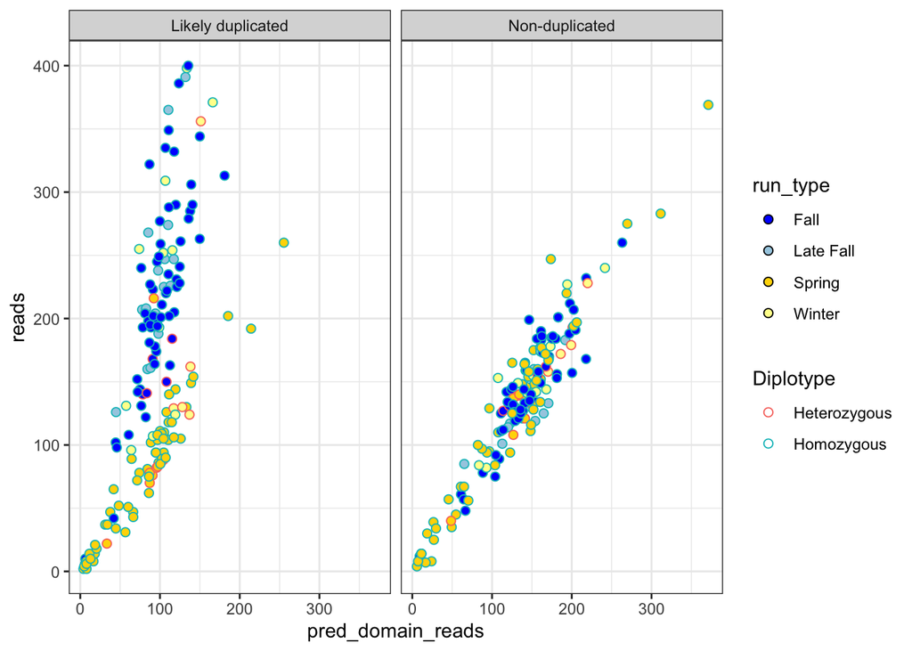

```r
ggplot(indy_pred_by_spring, aes(x = pred_domain_reads, y = reads, fill = run_type, colour = Diplotype)) +
  geom_point(shape = 21, size = 2.0) +
  facet_wrap(~Domain) +
  scale_fill_manual(values = fcolors_all_sf) +
  theme_bw()
```

I don’t really find the diplotype designation helpful there, other than to see that the one springer up with the blues is a het. So, let’s just not use that.

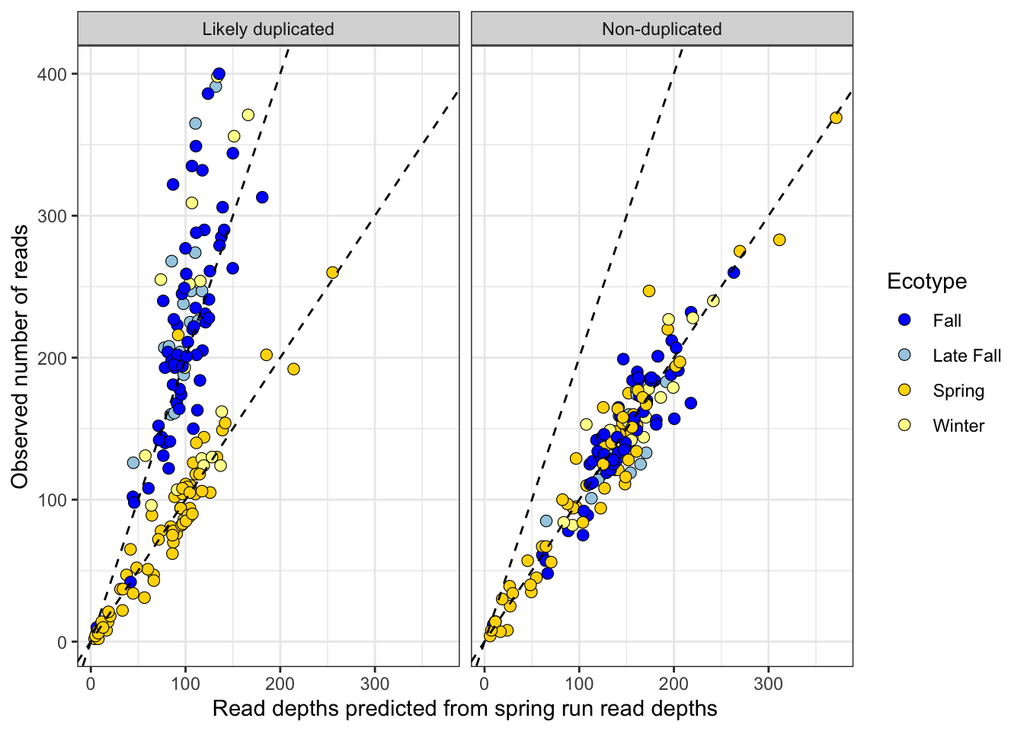

```r
g101 <- ggplot(indy_pred_by_spring, aes(x = pred_domain_reads, y = reads, fill = run_type)) +
  geom_point(shape = 21, size = 2.5, stroke = 0.3) +
  facet_wrap(~Domain) +
  scale_fill_manual(values = fcolors_all_sf) +
  theme_bw() +
  geom_abline(slope = c(1, 2), intercept = 0, linetype = "dashed") +
  guides(fill = guide_legend(title = "Ecotype")) +
  xlab("Read depths predicted from spring run read depths") +
  ylab("Observed number of reads")

ggsave(g101, filename = "outputs/008/dupie-read-depth-scatter.pdf", width = 8, height = 5)

g101
```

That is the final figure for this notebook.

# Running Time

Running the code and rendering this notebook required approximately this much time on a Mac laptop of middling speed:

```r
Sys.time() - start_time
```

```
## Time difference of 58.48034 secs
```

Citations